# Practical Machine Learning Project : Predict activity quality from activity monitors

Yan Zhai

1/28/2022

# Background

Using devices such as Jawbone Up, Nike FuelBand, and Fitbit it is now possible to collect a large amount of data about personal activity relatively inexpensively. These type of devices are part of the quantified self movement – a group of enthusiasts who take measurements about themselves regularly to improve their health, to find patterns in their behavior, or because they are tech geeks. One thing that people regularly do is quantify how much of a particular activity they do, but they rarely quantify how well they do it. In this project, your goal will be to use data from accelerometers on the belt, forearm, arm, and dumbell of 6 participants. They were asked to perform barbell lifts correctly and incorrectly in 5 different ways.

More information is available from the website here: http://web.archive.org/web/20161224072740/http:/groupware.les.inf.puc-rio.br/har (see the section on the Weight Lifting Exercise Dataset).

# Data Loading and Exploratory Analysis

## Dataset overview

The training data for this project are available here:

https://d396qusza40orc.cloudfront.net/predmachlearn/pml-training.csv

The test data are available here:

https://d396qusza40orc.cloudfront.net/predmachlearn/pml-testing.csv

The goal of our project is to predict the manner in which they did the exercise. The outcome variable is `classe`, a factor variable with 5 levels. A short description of `classe` variable is from the authors’ website:

"Six young health participants were asked to perform one set of 10 repetitions of the Unilateral Dumbbell Biceps Curl in five different fashions: exactly according to the specification (Class A), throwing the elbows to the front (Class B), lifting the dumbbell only halfway (Class C), lowering the dumbbell only halfway (Class D) and throwing the hips to the front (Class E).

Class A corresponds to the specified execution of the exercise, while the other 4 classes correspond to common mistakes."

## Environment Preparation

We first free up memory and then upload the R libraries that are necessary for the complete analysis. We also set seed for reproducability.

```r
# free up memory for the download of the data sets
rm(list=ls())

library(knitr)
library(lattice)
library(ggplot2)
library(caret)
library(corrplot)
library(randomForest)
library(rpart)
library(rpart.plot)
library(rattle)
library(corrplot)
```

```r
# Set seed for reproducability
set.seed(9999)
```

## Data loading and spliting

The next step is loading the data set from the URL provided above. The `training` data is used to devise training and testing sets. The `test` data is used to predict and answer the 20 questions based on the trained model.

```r
UrlTrain <- "http://d396qusza40orc.cloudfront.net/predmachlearn/pml-training.csv"
UrlTest  <- "http://d396qusza40orc.cloudfront.net/predmachlearn/pml-testing.csv"


training <- read.csv(url(UrlTrain), na.strings=c("NA","#DIV/0!", ""))
dim(training)
```

```
[1] 19622   160
```

```r
test  <- read.csv(url(UrlTest), na.strings=c("NA","#DIV/0!", ""))
dim(test)
```

```
[1]  20 160
```

Both created data sets have 160 variables.

## Data cleaning

Those variables have plenty of NA, which can be removed with the cleaning procedures below. The Near Zero variance (NZV) variables as well as the ID variables are also removed.

```r
# Remove NA. A threshold of 95 % is selected
na_var <- sapply(training, function(x) mean(is.na(x))) > 0.95
train_set <- training[ , na_var == FALSE]
test_set  <- test[ , na_var == FALSE]

# Remove NZV variables
nzv_var <- nearZeroVar(train_set)
train_set <- train_set[ , -nzv_var]
test_set  <- test_set [ , -nzv_var]

# Remove columns 1 to 5 (identification variables)
train_set <- train_set[ , -(1:5)]
test_set  <- test_set [ , -(1:5)]

dim(train_set)
```

```
[1] 19622    54
```

```r
dim(test_set)
```

```
[1] 20 54
```

After data cleaning, the data set remains 54 variables for further analysis.

## Cross validation

Cross-validation is a resampling method that uses different portions of the data to test and train a model on different iterations. The `train_set` data is then split in 2 to create a Train set (70% of the data) for the modeling process and a Test set (with the remaining 30%) for the validations. The `test_set` data set is not changed and will only be used for the quiz results generation.

```r
inTrain  <- createDataPartition(train_set$classe, p=0.70, list=FALSE)
sub_train <- train_set[inTrain, ]
sub_test  <- train_set[-inTrain, ]

dim(sub_train)
```

```
[1] 13737    54
```

```r
dim(sub_test)
```

```
[1] 5885   54
```

## Expected out-of-sample error

The expected out-of-sample error will correspond to the accuracy in the cross validation data. Accuracy is the proportion of correct classified observation over the total sample in the sub-testing data set. Expected accuracy is the expected accuracy in the out-of-sample data set.

## EDA

The outcome variable `classe` contains 5 levels. We plot this variable showing the frequency of each class level in the `sub_train` data. The plot indicates that Class A has highest frequency.

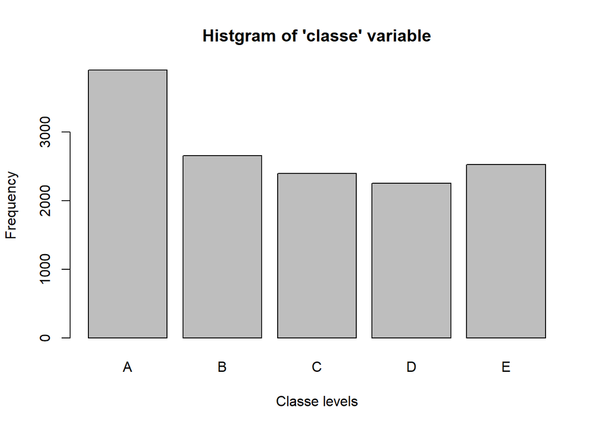

```r
plot(sub_train$classe, main="Histgram of 'classe' variable", xlab="Classe levels", ylab="Frequency")
```

# Prediction Model Building

With `sub_train` data, we create three models based on the regression methods including generalized boosted model, decision tree,and random forests. We also calculate the accuracy of each model for further comparison to find the best model for the prediction exercise.

## General Boosted Model

```r
set.seed(112233)

# Set up train control
traincrl_GBM <- trainControl(method = "repeatedcv", number = 5, repeats = 2)
# Fit the model
model_GBM  <- train(classe ~ ., data = sub_train, method = "gbm",
                  trControl = traincrl_GBM, verbose = FALSE)
model_GBM$finalModel
```

```
A gradient boosted model with multinomial loss function.
150 iterations were performed.
There were 53 predictors of which 53 had non-zero influence.
```

We make the prediction of `classe` variable based on this general boosted model, and compare the predicted values with actual `sub_test` data set. The accuracy of this model is 0.9867.

```r
# Perform prediction
predict_GBM <- predict(model_GBM, newdata = sub_test)
# Confusion matrix
conf_matrix_GBM <- confusionMatrix(table(predict_GBM, sub_test$classe))
conf_matrix_GBM
```

```
Confusion Matrix and Statistics


predict_GBM    A    B    C    D    E
          A 1671   14    0    0    0
          B    3 1105    7    4    2
          C    0   18 1013    5    4
          D    0    2    5  951    9
          E    0    0    1    4 1067

Overall Statistics

               Accuracy : 0.9867
                 95% CI : (0.9835, 0.9895)
    No Information Rate : 0.2845
    P-Value [Acc > NIR] : < 2.2e-16

                  Kappa : 0.9832

 Mcnemar's Test P-Value : NA

Statistics by Class:

                     Class: A Class: B Class: C Class: D Class: E
Sensitivity            0.9982   0.9701   0.9873   0.9865   0.9861
Specificity            0.9967   0.9966   0.9944   0.9967   0.9990
Pos Pred Value         0.9917   0.9857   0.9740   0.9835   0.9953
Neg Pred Value         0.9993   0.9929   0.9973   0.9974   0.9969
Prevalence             0.2845   0.1935   0.1743   0.1638   0.1839
Detection Rate         0.2839   0.1878   0.1721   0.1616   0.1813
Detection Prevalence   0.2863   0.1905   0.1767   0.1643   0.1822
Balanced Accuracy      0.9974   0.9834   0.9909   0.9916   0.9925
```

## Decision Tree Model

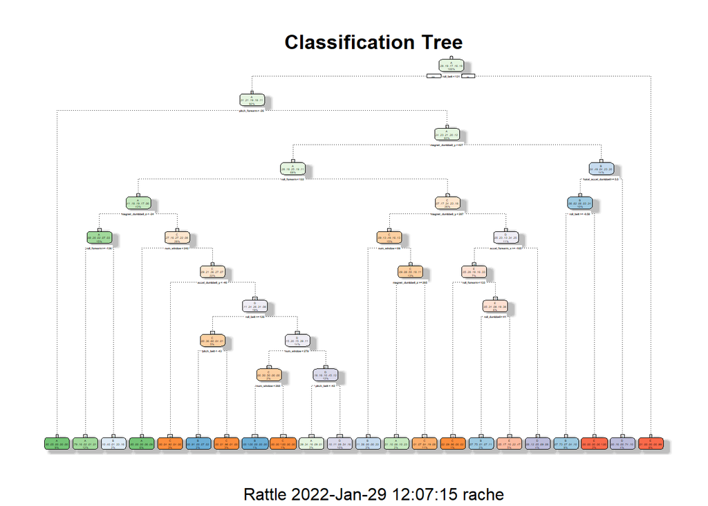

```r
set.seed(445566)
# Fit the model
model_DT <- rpart(classe ~ ., data = sub_train, method="class")
fancyRpartPlot(model_DT, main="Classification Tree")
```

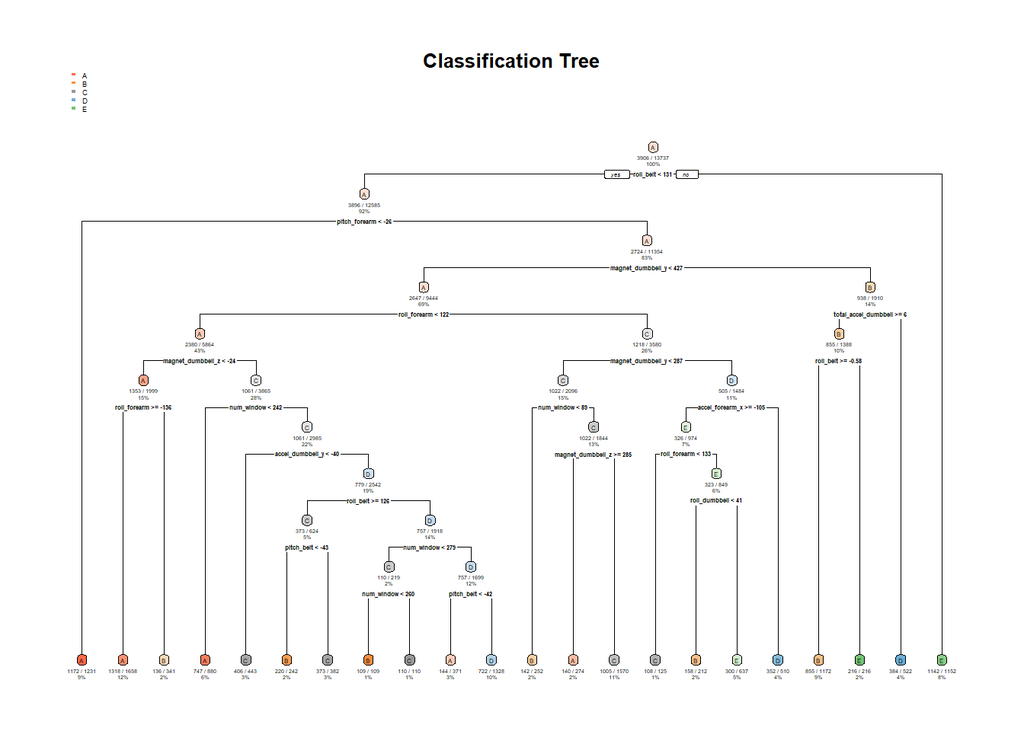

```r
rpart.plot(model_DT, main="Classification Tree", extra=102, under=TRUE, faclen=0)
```

We make the prediction of `classe` variable based on this decision tree model, and compare the predicted values with actual `sub_test` data set. The accuracy of this model is 0.7415.

```r
# Perform prediction
predict_DT <- predict(model_DT, newdata = sub_test, type="class")
# Confusion matrix
conf_matrix_DT <- confusionMatrix(table(predict_DT, sub_test$classe))
conf_matrix_DT
```

```
Confusion Matrix and Statistics


predict_DT    A    B    C    D    E
         A 1509  217   60   51   59
         B   71  674   52   82  116
         C    6   66  835  141   73
         D   67  135   52  631  119
         E   21   47   27   59  715

Overall Statistics

               Accuracy : 0.7415
                 95% CI : (0.7302, 0.7527)
    No Information Rate : 0.2845
    P-Value [Acc > NIR] : < 2.2e-16

                  Kappa : 0.6717

 Mcnemar's Test P-Value : < 2.2e-16

Statistics by Class:

                     Class: A Class: B Class: C Class: D Class: E
Sensitivity            0.9014   0.5917   0.8138   0.6546   0.6608
Specificity            0.9081   0.9324   0.9411   0.9242   0.9679
Pos Pred Value         0.7959   0.6774   0.7449   0.6285   0.8228
Neg Pred Value         0.9586   0.9049   0.9599   0.9318   0.9268
Prevalence             0.2845   0.1935   0.1743   0.1638   0.1839
Detection Rate         0.2564   0.1145   0.1419   0.1072   0.1215
Detection Prevalence   0.3222   0.1691   0.1905   0.1706   0.1477
Balanced Accuracy      0.9048   0.7621   0.8775   0.7894   0.8144
```

## Random forest

```r
set.seed(778899)
# Set up train control
ctrl_RF <- trainControl(method = "repeatedcv", number = 5, repeats = 2)
# Fit the model
model_RF  <- train(classe ~ ., data = sub_train, method = "rf",
                 trControl = ctrl_RF, verbose = FALSE)
model_RF$finalModel
```

```
Call:
 randomForest(x = x, y = y, mtry = param$mtry, verbose = FALSE)
               Type of random forest: classification
                     Number of trees: 500
No. of variables tried at each split: 27

        OOB estimate of  error rate: 0.23%
Confusion matrix:
     A    B    C    D    E  class.error
A 3905    0    0    0    1 0.0002560164
B    7 2648    3    0    0 0.0037622272
C    0    7 2388    1    0 0.0033388982
D    0    0    6 2246    0 0.0026642984
E    0    1    0    5 2519 0.0023762376
```

We make the prediction of `classe` variable based on this random forest model, and compare the predicted values with actual `sub_test` data set. The accuracy of this model is 0.9985.

```r
# Perform prediction
predict_RF <- predict(model_RF, newdata = sub_test)
# Confusion matrix
conf_matrix_RF <- confusionMatrix(table(predict_RF, sub_test$classe))
conf_matrix_RF
```

```
Confusion Matrix and Statistics


predict_RF    A    B    C    D    E
         A 1673    0    0    0    0
         B    1 1139    1    0    0
         C    0    0 1025    3    0
         D    0    0    0  960    3
         E    0    0    0    1 1079

Overall Statistics

               Accuracy : 0.9985
                 95% CI : (0.9971, 0.9993)
    No Information Rate : 0.2845
    P-Value [Acc > NIR] : < 2.2e-16

                  Kappa : 0.9981

 Mcnemar's Test P-Value : NA

Statistics by Class:

                     Class: A Class: B Class: C Class: D Class: E
Sensitivity            0.9994   1.0000   0.9990   0.9959   0.9972
Specificity            1.0000   0.9996   0.9994   0.9994   0.9998
Pos Pred Value         1.0000   0.9982   0.9971   0.9969   0.9991
Neg Pred Value         0.9998   1.0000   0.9998   0.9992   0.9994
Prevalence             0.2845   0.1935   0.1743   0.1638   0.1839
Detection Rate         0.2843   0.1935   0.1742   0.1631   0.1833
Detection Prevalence   0.2843   0.1939   0.1747   0.1636   0.1835
Balanced Accuracy      0.9997   0.9998   0.9992   0.9976   0.9985
```

# Evaluate the Models

# Expected out-of-sample error

With an accuracy above 99% on our cross-validation data, we can expect that very few, or none, of the test samples will be missclassified.

# Conclusion

The Random Forest model is selected and applied to make predictions on the 20 data points from the original testing data set.

# Applying the Selected Model to the Test Data

```r
predictTEST <- predict(model_RF, newdata=test)
predictTEST
```

```
 [1] B A B A A E D B A A B C B A E E A B B B
Levels: A B C D E
```